# Chapter 6: Analysis of longitudinal data

## Implementing the analyses of Chapter 8 of MABS using the RATS data

Here we will be working with longitudinal data from a study on rats, which were divided into different groups and put on various diets. Their body weights were recorded repeatedly over a nine-week period. The study’s primary focus is to assess whether the growth profiles differ across these dietary groups. This information is foundational for conducting analyses on how the different diets may affect the rats’ growth over time.

```r
# Loading required libraries
library(ggplot2)
library(dplyr)
library(lme4)
# Setting chunk options to ensure all R code is visible in the knitted document
knitr::opts_chunk$set(echo = TRUE)

# Loading and preparing the RATS data
rats_data <- read.csv("/Users/annatolonen/Desktop/IODS-project/data/RATS_long.csv", header = TRUE)
rats_data$ID <- factor(rats_data$ID)
rats_data$Group <- factor(rats_data$Group)
rats_data$Time <- factor(rats_data$Time)
```

Now that the data has been prepared, I’m going to move onto graphical displays of the longitudinal data in order to expose patterns in the data.

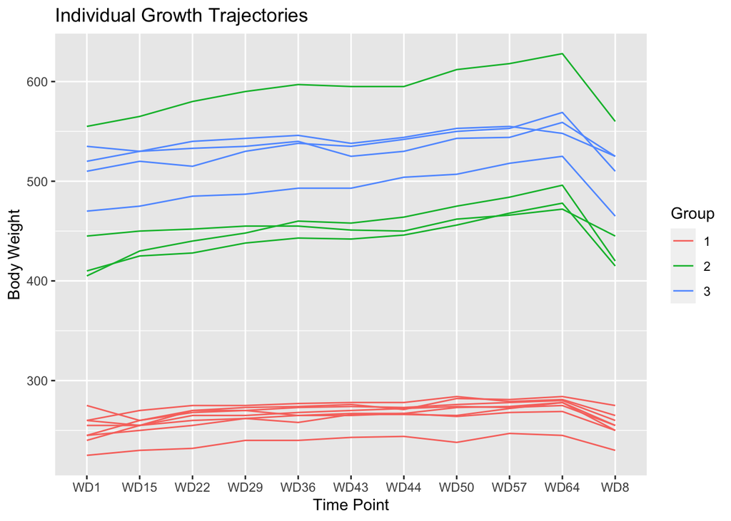

```r
# Individual Response profiles
# Plotting individual response profiles
ggplot(rats_data, aes(x = Time, y = value, group = ID, color = Group)) +
  geom_line() +
  labs(title = "Individual Growth Trajectories", x = "Time Point", y = "Body Weight")
```

Now onto standardizing the data and repearing the plotting of individual response profiles on the standardized data.

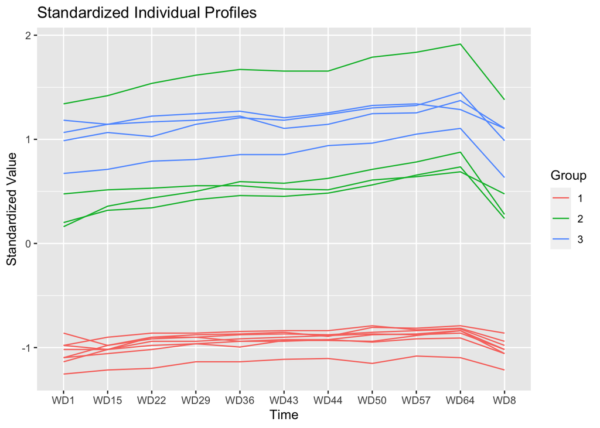

```r
# Standardizing the 'value' variable
rats_data$value_z <- scale(rats_data$value)

# Plotting the standardized individual response profiles
ggplot(rats_data, aes(x = Time, y = value_z, group = ID, color = Group)) +
  geom_line() +
  labs(title = "Standardized Individual Profiles", x = "Time", y = "Standardized Value")
```

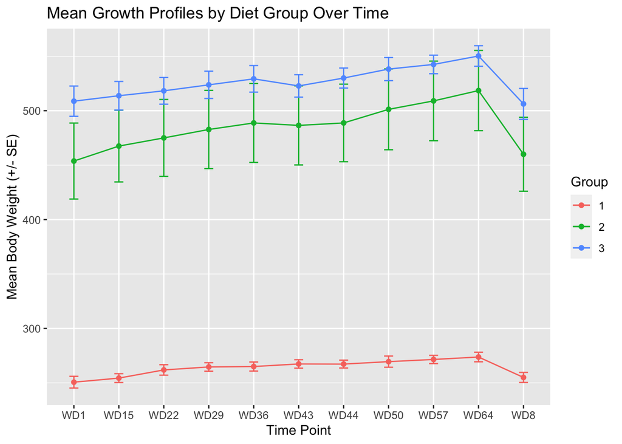

```r
# Calculating summary statistics (mean and standard error) by group and time
rats_summary_stats <- rats_data %>%
  group_by(Group, Time) %>%
  summarise(
    mean_value = mean(value),
    std_error = sd(value) / sqrt(n()),
    .groups = "drop" # Avoids carrying over grouping to the next operations
  )

# Plot mean growth profiles with error bars representing standard errors
ggplot(rats_summary_stats, aes(x = Time, y = mean_value, group = Group, color = Group)) +
  geom_errorbar(aes(ymin = mean_value - std_error, ymax = mean_value + std_error), width = 0.2) +
  geom_line() +
  geom_point() +
  labs(title = "Mean Growth Profiles by Diet Group Over Time", x = "Time Point", y = "Mean Body Weight (+/- SE)")
```

**Interpretation**: Error bars provide an estimate of variability around the mean at each time point. Consistent patterns or deviations from group trends can suggest differences in diet efficacy or variability in response to diet.It seems that in this case Group 3, which is represented by the blue line, has consistently higher mean body weights throughout the study period. This could indicate that the diet associated with Group 3 is more effective at promoting growth. On the other hand, Group 1, shown in red, has the lowest mean body weights, which may suggest that its diet is less effective. Additionally, the overlapping error bars between Groups 2 and 3 at most time points suggest that while their mean body weights are different, the differences are not always statistically significant. The clear separation of Group 1 from the other two groups across all time points, however, indicates a statistically significant difference.

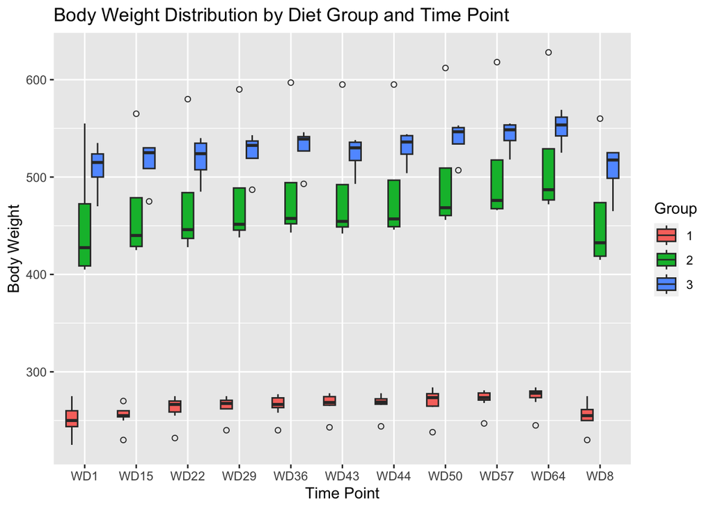

```r
# Creating boxplots of body weight by group at each time point to potentially show distribution, central tendency, and outliers
ggplot(rats_data, aes(x = Time, y = value, fill = Group)) +
  geom_boxplot(outlier.shape = 1) +
  labs(title = "Body Weight Distribution by Diet Group and Time Point", x = "Time Point", y = "Body Weight")
```

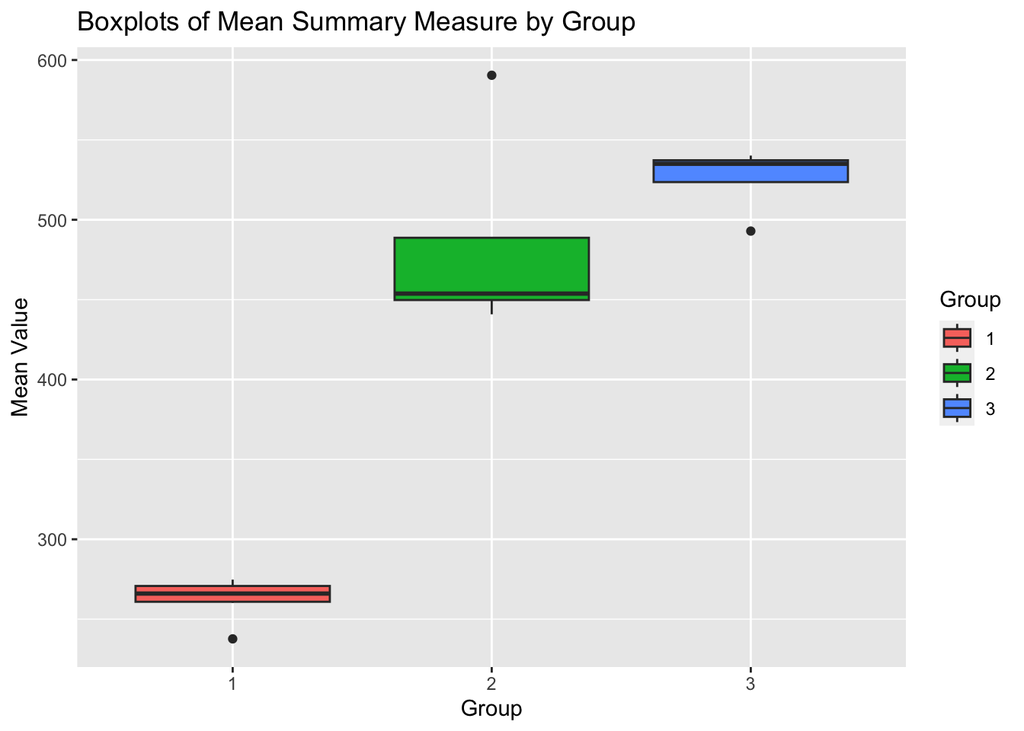

```r
# Calculating the mean value for each individual across all time points
rats_summary <- aggregate(value ~ ID + Group, data = rats_data, FUN = mean)

# Renaming the aggregated value to 'mean_value'
names(rats_summary)[names(rats_summary) == "value"] <- "mean_value"

# Creating boxplots of the mean summary measure for each group
ggplot(rats_summary, aes(x = Group, y = mean_value, fill = Group)) +
  geom_boxplot() +
  labs(title = "Boxplots of Mean Summary Measure by Group", x = "Group", y = "Mean Value")
```

**Interpetation**:

The boxplot suggests that the treatment or condition associated with Group 3 might be leading to higher mean values on the measured response compared to the other two groups. It also indicates that there’s more variability in the response within Groups 2 and 3 compared to Group 1. The presence of outliers could warrant further investigation to understand why those individual responses are different from the rest.

```r
# Statistical analysis to compare mean body weight between diet groups
anova_result <- aov(mean_value ~ Group, data = rats_summary)
summary(anova_result)
```

```
##             Df Sum Sq Mean Sq F value   Pr(>F)
## Group        2 236732  118366   88.07 2.76e-08 ***
## Residuals   13  17471    1344
## ---
## Signif. codes:  0 '***' 0.001 '**' 0.01 '*' 0.05 '.' 0.1 ' ' 1
```

**Interpretation**: ANOVA results suggest significant differences in mean body weight between diet groups. In other words, the variation in body weight among the different diet groups is statistically significant and not likely due to random chance. Specifically, the F value of 88.07 is large and, combined with the very small p-value (2.76e-08), provides strong evidence against the null hypothesis of no difference in means across the groups. Consequently, we can infer that diet has a measurable impact on the growth of the rats. Given the degrees of freedom for the group is 2, this indicates that at least one group’s mean body weight is significantly different from the others, warranting further post-hoc analysis to pinpoint the exact nature of these differences.”

```r
# Post-hoc test to compare mean differences between each pair of diet groups
posthoc_result <- TukeyHSD(anova_result)

# Mixed-effects model to account for non-independence of repeated measures within rats
mixed_model <- lmer(value ~ Time * Group + (1 | ID), data = rats_data)
summary(mixed_model)
```

```
## Linear mixed model fit by REML ['lmerMod']
## Formula: value ~ Time * Group + (1 | ID)
##    Data: rats_data
##
## REML criterion at convergence: 1062.8
##
## Scaled residuals:
##     Min      1Q  Median      3Q     Max
## -2.6733 -0.4079  0.0162  0.4514  3.3388
##
## Random effects:
##  Groups   Name        Variance Std.Dev.
##  ID       (Intercept) 1340.34  36.611
##  Residual               39.77   6.306
## Number of obs: 176, groups:  ID, 16
##
## Fixed effects:
##                 Estimate Std. Error t value
## (Intercept)      250.625     13.134  19.081
## TimeWD15           3.750      3.153   1.189
## TimeWD22          11.250      3.153   3.568
## TimeWD29          14.000      3.153   4.440
## TimeWD36          14.375      3.153   4.559
## TimeWD43          16.750      3.153   5.312
## TimeWD44          16.625      3.153   5.272
## TimeWD50          18.875      3.153   5.986
## TimeWD57          20.875      3.153   6.620
## TimeWD64          23.125      3.153   7.334
## TimeWD8            4.375      3.153   1.387
## Group2           203.125     22.750   8.929
## Group3           258.125     22.750  11.346
## TimeWD15:Group2   10.000      5.462   1.831
## TimeWD22:Group2   10.000      5.462   1.831
## TimeWD29:Group2   15.000      5.462   2.746
## TimeWD36:Group2   20.625      5.462   3.776
## TimeWD43:Group2   16.000      5.462   2.930
## TimeWD44:Group2   18.375      5.462   3.364
## TimeWD50:Group2   28.625      5.462   5.241
## TimeWD57:Group2   34.375      5.462   6.294
## TimeWD64:Group2   41.625      5.462   7.622
## TimeWD8:Group2     1.875      5.462   0.343
## TimeWD15:Group3    1.250      5.462   0.229
## TimeWD22:Group3   -1.750      5.462  -0.320
## TimeWD29:Group3    1.000      5.462   0.183
## TimeWD36:Group3    6.125      5.462   1.121
## TimeWD43:Group3   -2.750      5.462  -0.504
## TimeWD44:Group3    4.625      5.462   0.847
## TimeWD50:Group3   10.625      5.462   1.945
## TimeWD57:Group3   12.875      5.462   2.357
## TimeWD64:Group3   18.375      5.462   3.364
## TimeWD8:Group3    -6.875      5.462  -1.259
```

```
##
## Correlation matrix not shown by default, as p = 33 > 12.
## Use print(x, correlation=TRUE)  or
##     vcov(x)        if you need it
```

## Implementing the analyses of Chapter 9 of MABS using the BPRS data

Here we are working with data tracking the Brief Psychiatric Rating Scale (BPRS) scores of patients undergoing different treatments over a set period. The data tracks the effectiveness of treatments across different time points, allowing for the analysis of changes in psychiatric symptoms over time.

```r
# Loading the BPRS dataset
BPRS <- read.csv("/Users/annatolonen/Desktop/IODS-project/data/BPRS_long.csv")

# Prepare the data by converting factor columns to factor type
BPRS <- BPRS %>%
  mutate(
    subject = as.factor(subject),
    treatment = as.factor(treatment),
    week = as.factor(week)
  )

# Glimpse of the BPRS data
glimpse(BPRS)
```

```
## Rows: 360
## Columns: 4
## $ treatment <fct> 1, 1, 1, 1, 1, 1, 1, 1, 1, 1, 1, 1, 1, 1, 1, 1, 1, 1, 1, 1, …
## $ subject   <fct> 1, 1, 1, 1, 1, 1, 1, 1, 1, 2, 2, 2, 2, 2, 2, 2, 2, 2, 3, 3, …
## $ week      <fct> week0, week1, week2, week3, week4, week5, week6, week7, week…
## $ value     <int> 42, 36, 36, 43, 41, 40, 38, 47, 51, 58, 68, 61, 55, 43, 34, …
```

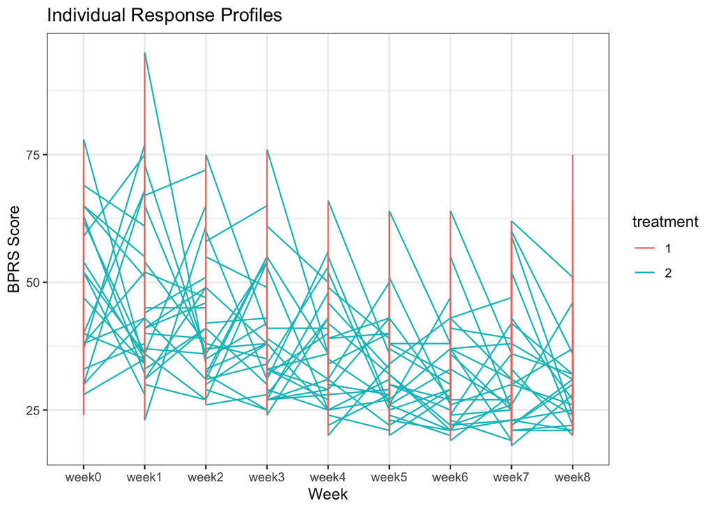

```r
# Plotting individual response profiles for BPRS
ggplot(BPRS, aes(x = week, y = value, group = subject, color = treatment)) +
  geom_line() +
  theme_bw() +
  labs(title = "Individual Response Profiles", x = "Week", y = "BPRS Score")
```

**Interpretation**:

The plot shows individual response profiles over time for two different treatment groups in the BPRS dataset. The BPRS score is a measure of psychiatric symptoms, and lower scores generally indicate fewer or less severe symptoms. Here, we observe variability within and between treatment groups over the weeks. There are spikes in BPRS scores for some individuals at different time points, which could indicate episodes of symptom exacerbation. The red lines represent one treatment group and the cyan lines represent another. Without further context, it’s hard to determine the causes of these variations, but they could be due to individual responses to treatment, measurement error, or other factors not captured in the data.

```r
# Fitting a linear model for BPRS
BPRS_reg <- lm(value ~ week + treatment, data = BPRS)
summary(BPRS_reg)
```

```
##
## Call:
## lm(formula = value ~ week + treatment, data = BPRS)
##
## Residuals:
##     Min      1Q  Median      3Q     Max
## -23.714  -9.226  -2.989   6.786  48.389
##
## Coefficients:
##             Estimate Std. Error t value Pr(>|t|)
## (Intercept)  47.7139     2.0590  23.173  < 2e-16 ***
## weekweek1    -1.6750     2.7624  -0.606  0.54467
## weekweek2    -6.3000     2.7624  -2.281  0.02317 *
## weekweek3    -8.8500     2.7624  -3.204  0.00148 **
## weekweek4   -11.6500     2.7624  -4.217 3.15e-05 ***
## weekweek5   -15.4500     2.7624  -5.593 4.51e-08 ***
## weekweek6   -16.7750     2.7624  -6.073 3.28e-09 ***
## weekweek7   -15.8000     2.7624  -5.720 2.29e-08 ***
## weekweek8   -16.5750     2.7624  -6.000 4.92e-09 ***
## treatment2    0.5722     1.3022   0.439  0.66063
## ---
## Signif. codes:  0 '***' 0.001 '**' 0.01 '*' 0.05 '.' 0.1 ' ' 1
##
## Residual standard error: 12.35 on 350 degrees of freedom
## Multiple R-squared:  0.2026, Adjusted R-squared:  0.182
## F-statistic: 9.878 on 9 and 350 DF,  p-value: 1.62e-13
```

**Interpretation**: The summary output from the linear model shows that there is a statistically significant decrease in BPRS scores over the weeks, indicating an overall improvement in the psychiatric symptoms measured by the BPRS scale. This is shown by the negative coefficients for weeks 2 through 8, which have p-values less than 0.05, signifying that these time points have significantly lower scores than the baseline (week 0). The coefficient for treatment2 is not statistically significant (p-value = 0.66063), suggesting that there is no significant difference between the two treatment groups regarding their effect on BPRS scores when not considering the time effect. The residuals of the model indicate the differences between the observed and predicted BPRS scores, with a range from approximately -23.7 to 48.4, which could suggest variability in individual responses to treatment or other unmeasured factors.

```r
# Fitting a mixed-effects model for BPRS
BPRS_lme <- lmer(value ~ week + treatment + (1 | subject), data = BPRS, REML = FALSE)
summary(BPRS_lme)
```

```
## Linear mixed model fit by maximum likelihood  ['lmerMod']
## Formula: value ~ week + treatment + (1 | subject)
##    Data: BPRS
##
##      AIC      BIC   logLik deviance df.resid
##   2751.3   2798.0  -1363.7   2727.3      348
##
## Scaled residuals:
##     Min      1Q  Median      3Q     Max
## -3.2309 -0.6213 -0.1018  0.4877  3.3537
##
## Random effects:
##  Groups   Name        Variance Std.Dev.
##  subject  (Intercept)  47.6     6.899
##  Residual             100.8    10.039
## Number of obs: 360, groups:  subject, 20
##
## Fixed effects:
##             Estimate Std. Error t value
## (Intercept)  47.7139     2.2758  20.965
## weekweek1    -1.6750     2.2448  -0.746
## weekweek2    -6.3000     2.2448  -2.807
## weekweek3    -8.8500     2.2448  -3.942
## weekweek4   -11.6500     2.2448  -5.190
## weekweek5   -15.4500     2.2448  -6.883
## weekweek6   -16.7750     2.2448  -7.473
## weekweek7   -15.8000     2.2448  -7.039
## weekweek8   -16.5750     2.2448  -7.384
## treatment2    0.5722     1.0582   0.541
##
## Correlation of Fixed Effects:
##            (Intr) wekwk1 wekwk2 wekwk3 wekwk4 wekwk5 wekwk6 wekwk7 wekwk8
## weekweek1  -0.493
## weekweek2  -0.493  0.500
## weekweek3  -0.493  0.500  0.500
## weekweek4  -0.493  0.500  0.500  0.500
## weekweek5  -0.493  0.500  0.500  0.500  0.500
## weekweek6  -0.493  0.500  0.500  0.500  0.500  0.500
## weekweek7  -0.493  0.500  0.500  0.500  0.500  0.500  0.500
## weekweek8  -0.493  0.500  0.500  0.500  0.500  0.500  0.500  0.500
## treatment2 -0.232  0.000  0.000  0.000  0.000  0.000  0.000  0.000  0.000
```

**Interpretation**: The output from the mixed-effects model indicates that, like the linear model, there is a significant decrease in BPRS scores over the weeks. This decrease is consistent across weeks 2 through 8, similar to the linear model results. However, the mixed-effects model also accounts for variability among subjects with random effects, which are captured in the variance and standard deviation under ‘Random effects’. The standard deviation of the intercept for subject suggests individual differences in baseline BPRS scores.

The non-significant coefficient for treatment2 again indicates that the difference between the two treatments is not statistically significant when considering the entire study period. The correlation of fixed effects shows that the weeks are not independent of each other; however, treatment is not correlated with the week effects, suggesting that the progression over time is not different between treatments.